# Quark/gluon jet discrimination: a reproducible analysis using R

# Relation to other quantities

Mutual information can be equivalently expressed as:

$$\begin{equation}
I(X;Y) = H(X) + H(Y) - H(X,Y)
\end{equation}$$

where $H(X)$ and $H(Y)$ are the marginal Shannon entropies of $X$ and $Y$ respectively:

$$\begin{equation}
H\left(X\right) = -\sum\limits_{x \in X} p(x) \log_{2} p(x)
\end{equation}$$

and $H(X,Y)$ is the joint entropy of $X$ and $Y$:

$$\begin{equation}
H\left(X,Y\right) = -\sum\limits_{y \in Y}\sum\limits_{x \in X} p(x,y) \log_{2} p(x,y)
\end{equation}$$

# Symmetric uncertainty

The following is a normalized variant of the mutual information:

$$\begin{equation}
U\left(X,Y\right) = 2\frac{I(X;Y)}{H(X) + H(Y)}
\end{equation}$$

The mutual information is estimated from the data using frequency counts in histogram bins.

There are several strategies for doing this. The simplest estimator is the empirical (or “naive”) MI estimator that gives the maximum-likelihood entropy estimate for a discretised random variable. It is known that this is a biased estimator due to undersampling of the cell frequencies with increasing number of bins. We found the Miller-Madow asymptotic bias-corrected estimator to be most suitable for our needs, and it is simpler than the shrinkage or Schürmann-Grassberger estimators that uses the Dirichlet probability distribution as conjugate prior for the likelihood given by the empirical estimator.

# Feature redundancy

- We’d like to pick features that have a strong association with the target (“quark”/“gluon”) but have weak association with each other

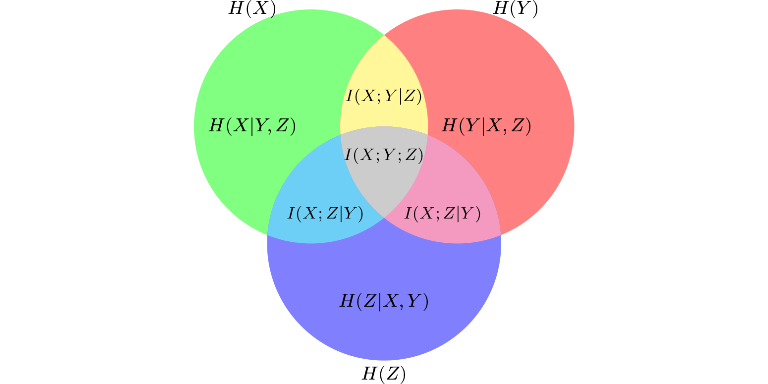

If Z is the target, for each X and Y measure the total *conditional mutual information* corresponding to the cyan and magenta regions. If the sum is large (and the grey region is small) then this is a good pairing. Note that the grey region (the *multivariate mutual information*) may be negative, meaning that a pair of features may synergise.

# Conditional mutual information

Conditional mutual information written in terms of joint and marginal Shannon entropies:

$$\begin{equation}
I(X;Y|Z) = H(X,Z) + H(Y,Z) - H(X,Y,Z) - H(Z)
\end{equation}$$

or, in terms of mutual information:

$$\begin{equation}
I(X;Y|Z) = I(X;Y,Z) - I(X;Z)
\end{equation}$$

# Model

- Our baseline model is ElasticNet, a generalised linear model that combines the $\ell_1$ and $\ell_2$ penalties of the LASSO (least absolute shrinkage and selection operator) and ridge methods:
  - $\ell_1$ is a LASSO penalty
  - $\ell_2$ is a ridge penalty, aka Tikhonov regularisation
- It’s basically logistic regression and fit via penalized maximum likelihood with the result that the coefficients shrink and can become zero, resulting in a sparse model
- Nested stratified k-fold cross validation was used to generate robust estimates of model performance:
  - The outer CV is used to estimate model performance; 5 folds
  - The inner CV is used for hyperparameter ($\alpha$, $\lambda$) tuning and model selection; 5 folds
- Created a custom metric to tune the probability threshold for a quark-tagging efficiency of 50%

# Logistic regression

Uses the function:

$$P(X) = \frac{e^{\theta_0 + \theta_1{x_1} + \cdots + \theta_p{x_p}}}{1+e^{\theta_0 + \theta_1{x_1} + \cdots + \theta_p{x_p}}}$$

A bit of rearrangement gives:

$$\log\left(\frac{P(X)}{1-P(X)}\right) = \theta_0 + \theta_1{x_1} + \cdots + \theta_p{x_p} = \Theta^T{X}$$

This transformation is called the *log odds* or *logit* of $P(X)$.

We want to find the values of the coefficients $\Theta$.

In ElasticNet, we contrain the size of coefficients by adding a combination of penalty functions based on $\|\Theta\|_1$ and $\|\Theta\|_2$.

# Coefficient shrinkage

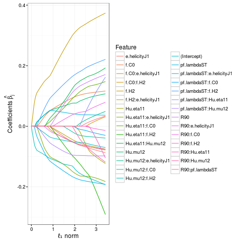

Coefficients versus $\ell_1$ norm. At the extreme left is the intercept only model, to the extreme right is the full least-squares fit.